# Ambulatory or residential? a multi-state analysis of treatments for substace use disorders (Step 2)

09 mayo, 2021

# Cumulative Transition Hazards of Joint Models

Cumulative baseline hazard can be estimated non-parametrically through a Breslow estimator. Must take note that we are assuming a semimarkov process in these transitions.

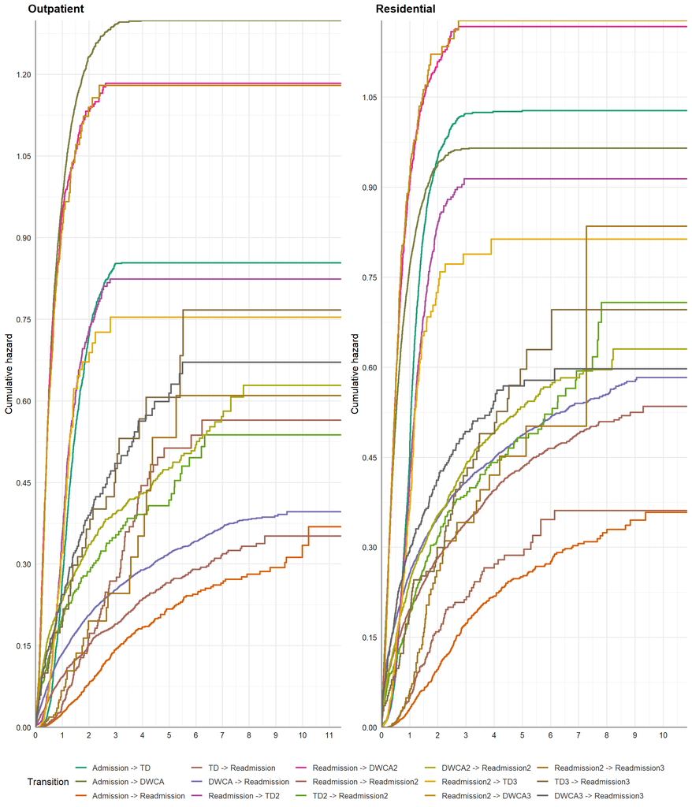

Figure 1. Estimate of Cumulative Hazards (Semimarkov), Stratified by Setting

```r
if(no_mostrar==1){
  for(i in c(1:3)){
    print(survdiff(Surv(time,status==1)~tipo_de_programa_2,data=subset(ms_CONS_C1_SEP_2020_women_imputed, trans == i)))
    }
  for(i in c(1:5)){
    print(survdiff(Surv(time,status==1)~tipo_de_programa_2,data=subset(ms2_CONS_C1_SEP_2020_women_imputed, trans == i)))
  }
}

#We consider first the model without any proportionality assumption on the baseline hazards; this is achieved by adding strata(trans) to the formula, which estimates separate baseline hazards for different values of trans (the transitions).

pr0 <- subset(ms_d_match_surv, tipo_de_plan_res_1==0)
pr1 <- subset(ms_d_match_surv, tipo_de_plan_res_1==1)
attr(pr0, "trans") <- trans_matrix
attr(pr1, "trans") <- trans_matrix

#Since there are tied event times, we need to specify ties="breslow" in order to obtain the Aalen-Johansen estimator of
#the transition probability
#If we only want the cumulative hazard for the relapse → death transition, we can
#select the rows that refer to transition 3.
#The stacked format allows to calculate all cumulative hazards via the basic coxph function.
c0 <- survival::coxph(Surv(time, status) ~ strata(trans), #Surv(time, status) ~ strata(trans)
            data = pr0, method = "breslow")
c1 <- survival::coxph(Surv(time, status) ~ strata(trans),
            data = pr1, method = "breslow")

#The value of time is equal to Tstop−Tstart; it is of use in ’clock reset’-models, where the time t refers to the time spent in the current state

#The alternative is to first apply the msfit function, which we also need when computing the transition
#probabilities
# piece-wise constant estimates - because is cox
msf0 <- mstate::msfit(object = c0, trans = trans_matrix, vartype ="aalen")
msf1 <- mstate::msfit(object = c1,  trans = trans_matrix, vartype ="aalen")

#Haz contains the estimated cumulative hazard for each of the transitions for the particular patient
#specified in newd, while varHaz contains the estimated variances of these cumulative hazards,
#as well as the covariances for each combination of two transitions. All are evaluated at the
#time points for which any event in any transition occurs, possibly augmented with the largest
#(non-event) time point in the data. The summary method for msfit objects is most conveniently
#used for a summary. If we also would like to have a look at the covariances, we could set the
#argument variance equal to TRUE.

#This is a list with elements Haz (with the estimated cumulative hazard values at all event
#times), varHaz (with the covariances of each pair of estimated cumulative hazards at each
#event time point, i.e., cov( c Abgh(t), Abkl(t))), and trans, in which the transition matrix is stored
#for further use. The (co)variances of the estimated cumulative hazards may be computed in
#two different ways: by means of the Aalen estimator or by means of the Greenwood estimator.
#An advantage of the Greenwood estimator is the fact that it yields exact multinomial standard
#errors for the transition probabilities when there is no censoring. The two estimators give
#almost equal results in all practical applications.

msf0_plot<-
plot(msf0,
     #cols=c()
     type="single",
     use.ggplot = TRUE)+
  ggtitle("")+
  ylim(0,1.5)+
  sjPlot::theme_sjplot2()+
  scale_x_continuous("",breaks=seq(0,max(newtime0,na.rm=T),by=365.25), labels=(1:length(seq(0,max(newtime0,na.rm=T),by=365.25))-1)) +
  theme(legend.position = "bottom")+
  scale_y_continuous(breaks=seq(0,1.5,by=1.5/10),limits=c(0,1.5))
msf1_plot<-
plot(msf1,
     #cols=c()
     type="single",
     use.ggplot = TRUE)+
  ggtitle("")+
  ylim(0,1.5)+
  sjPlot::theme_sjplot2()+
  scale_x_continuous("",breaks=seq(0,max(newtime0,na.rm=T),by=365.25), labels=(1:length(seq(0,max(newtime0,na.rm=T),by=365.25))-1)) +
  theme(legend.position = "bottom")+
  scale_y_continuous(breaks=seq(0,1.5,by=1.5/10),limits=c(0,1.5))
ggarrange(msf0_plot,msf1_plot,
          labels = c("Outpatient", "Residential"),
          common.legend = TRUE,
          #label.y="Cumulative Baseline Hazards",
         # label.x="Years",
          legend = "bottom")
```

```r
 if(no_mostrar==1){
jpeg("eso14.jpg", height=14, width= 12, res= 96, units = "in")

ggarrange(msf0_plot,msf1_plot,
          labels = c("Outpatient", "Residential"),
          common.legend = TRUE,
          #label.y="Cumulative Baseline Hazards",
         # label.x="Years",
          legend = "bottom")

dev.off()
}
```

```r
# Semi-parametric models
#Since there are tied event times, we need to specify ties="breslow" in order to obtain the Aalen-Johansen estimator of
#the transition probability

formula3<-
as.formula(paste0("Surv(time, status) ~", paste0(fitform2," + arrival + strata(trans)")[[3]]))

formula3_mstate<-
as.formula(paste0("Surv(time, status) ~", paste0(fitform2," + arrival")[[3]]))

formula3_mstate_b<-
as.formula(paste0("Surv(time, status) ~", paste0(fitform2," + arrival.1 + arrival.2 + arrival.3")[[3]]))

paste0("We introduced the following Formula: ")
formula3

#_#_#_#_#_#_#_#_#_#_#_#_#_#_#_#_#_#_#_#_#_#_#_#_#_#_#_#_#_#_#_#_#_#_#_#_#_#_#_#_
#_#_#_#_#_#_#_#_#_#_#_#_#_#_#_#_#_#_#_#_#_#_#_#_#_#_#_#_#_#_#_#_#_#_#_#_#_#_#_#_

cox_fits0_prog0 <- survival::coxph(Surv(time, status==1) ~ strata(trans) ,
                            data = subset(ms_d_match_surv, tipo_de_plan_res_1==0), method = "breslow")
cox_fits0_prog1 <- survival::coxph(Surv(time, status==1) ~ strata(trans) ,
                            data = subset(ms_d_match_surv, tipo_de_plan_res_1==1), method = "breslow")

cox_fits <- survival::coxph(formula3,
                            data = ms_d_match_surv, method = "breslow")

cox_fits_4s <- survival::coxph(formula3,
                            data = ms_d_match_surv, method = "breslow")
```

```r
# Semi-parametric models
#Since there are tied event times, we need to specify ties="breslow" in order to obtain the Aalen-Johansen estimator of
#the transition probability

#_#_#_#_#_#_#_#_#_#_#_#_#_#_#_#_#_#_#_#_#_#_#_#_#_#_#_#_#_#_#_#_#_#_#_#_#_#_#_#_
#_#_#_#_#_#_#_#_#_#_#_#_#_#_#_#_#_#_#_#_#_#_#_#_#_#_#_#_#_#_#_#_#_#_#_#_#_#_#_#_

cox_fits0_prog0 <- survival::coxph(Surv(time, status==1) ~ strata(trans) ,
                            data = subset(ms_CONS_C1_SEP_2020_women_imputed, tipo_de_programa_2==0), method = "breslow")
cox_fits0_prog1 <- survival::coxph(Surv(time, status==1) ~ strata(trans) ,
                            data = subset(ms_CONS_C1_SEP_2020_women_imputed, tipo_de_programa_2==1), method = "breslow")

cox_fits0_4s_prog0 <- survival::coxph(Surv(time, status==1) ~ strata(trans) ,
                            data = subset(ms2_CONS_C1_SEP_2020_women_imputed, tipo_de_programa_2==0), method = "breslow")
cox_fits0_4s_prog1 <- survival::coxph(Surv(time, status==1) ~ strata(trans) ,
                            data = subset(ms2_CONS_C1_SEP_2020_women_imputed, tipo_de_programa_2==1), method = "breslow")

cox_fits <- survival::coxph(formula3,
                            data = ms_CONS_C1_SEP_2020_women_imputed, method = "breslow")

cox_fits_4s <- survival::coxph(formula3,
                            data = ms2_CONS_C1_SEP_2020_women_imputed, method = "breslow")

#_#_#_#_#_#_#_#_#_#_#_#_#_#_#_#_#_#_#_#_#_#_#_#_#_#_#_#_#_#_#_#_#_#_#_#_#_#_
#_#_#_#_#_#_#_#_#_#_#_#_#_#_#_#_#_#_#_#_#_#_#_#_#_#_#_#_#_#_#_#_#_#_#_#_#_#_
# Parametric models

# Sin covs= Trans 1: Gompertz o Gen-gamma en visual y RMSE, sin covariables. Se repite en AIC; Trans 2: Gen-gamma y Gompertz en RMSE (gompertz, mejor extrapolaci´n); gen-gamma, mejor inicio. Le sigue Lognormal. En AIC, parte Gen-gamma, gompertz y lognormal; Trans 3: Gompertz, Log-logistic y Gen-gamma. En AIC, Log-logistic, Gen-gamma y Weibull. Gompertz se aleja mucho.
#
# Con covs= Trans 1: Gen-gamma y Gompertz en RMSE. Visualmente mejor gompertz. AIC mejor Gompertz, pero seguido de Gen-gamma; Trans 2: Gen-gamma, Lognormal y Gompertz. Visualmente Lognormal no destaca. AIC, gen-gamma, lognorma y un poco más atrás Gompertz; Trans 3: Gen-gamma, Log-logistic y Gamma. Gompertz se ve mejor, pero ni uno en verdad. AIC, Log-logistic, Gen-gamma y Lognormal.

#Gompertz, Gen-gamma, Log-logistic
#Gompertz, Gen-gamma, Gen-gamma
#Gompertz, Gompertz, Log-logistic
#Gommpertz, Gompertz, Gen-gamma
#Gen-gamma, Gen-gamma, Log-logistic
#Gen-gamma, Gen-gamma, Gen-gamma
#Gen-gamma, Gompertz, Log-logistic
#Gen-gamma, Gompertz, Gen-gamma

#_#_#_#_#_#_#_#_#_#_#_#_#_#_#_#_#_#_#_#_#_#_#_#_#_#_#_#_#_#_#_#_#_#_#_#_#_#_

#2021-04-10

#AIC
# 1.- GenF, Gompertz, Ggam
# 2.- GenF, Ggam., Logn
# 3.- Llogis, Weibull, Ggam, GenF -> Con covs: Gen F, LLogis, Ggam

#RMSE
# 1.- GenF, Gga,. Gompertz
# 2.- GenF, Ggam, Lognormal
# 3.- Lognormal, Ggam, GenF

#_#_#_#_#_#_#_#_#_#_#_#_#_#_#_#_#_#_#_#_#_#_#_#_#_#_#_#_#_#_#_#_#_#_#_#_#_#_

dists_w_covs_mstate<-
cbind(
formal= c("Gompertz", "Generalized gamma", "Log-logistic"),
model= c("gomp", "ggam", "llogis"),
dist= c("gompertz", "gengamma", "llogis"))
#“genf”, “genf.orig”, “gengamma”, “gengamma.orig”, “exp”, “weibull”, “weibullph”, “lnorm”, “gamma”, “gompertz”, “llogis”, “exponential”, “lognormal”

sel_param_fits_a <- vector(length = n_trans, mode = "list")
#for (i in 1:n_trans){
#  sel_param_fits_a[[i]] <- flexsurvreg(formula3_mstate,#formula3_mstate_b #fitform2_t3 #fitform2
#                       data = subset(ms_CONS_C1_SEP_2020_women_imputed, trans == i),#
#                       dist = as.character(dists_w_covs_mstate[i,"dist"]))
#}
# If I use formula3_mstate (include arrival term in every transition):
#Warning messages:
#1: In flexsurvreg(formula3_mstate, data = subset(ms2_CONS_C1_SEP_2020_women_imputed,  :
#  Optimisation has probably not converged to the maximum likelihood - Hessian is not positive definite.
#2: In flexsurvreg(formula3_mstate, data = subset(ms2_CONS_C1_SEP_2020_women_imputed,  :
#  Optimisation has probably not converged to the maximum likelihood - Hessian is not positive definite.
#3: In flexsurvreg(formula3_mstate, data = subset(ms2_CONS_C1_SEP_2020_women_imputed,  :
#  Optimisation has probably not converged to the maximum likelihood - Hessian is not positive definite.

#If I use formula fitform2_t3:
#Warning messages:
#1: In flexsurvreg(fitform2_t3, data = subset(ms_CONS_C1_SEP_2020_women_imputed,  :
#  Optimisation has probably not converged to the maximum likelihood - Hessian is not positive definite.
#2: In flexsurvreg(fitform2_t3, data = subset(ms_CONS_C1_SEP_2020_women_imputed,  :
#  Optimisation has probably not converged to the maximum likelihood - Hessian is not positive definite.

#If I use the formula formula3_mstate_b and expand.covs(ms_CONS_C1_SEP_2020_women_imputed,"arrival"), i get:
#Warning messages:
#1: In flexsurvreg(formula3_mstate_b, data = subset(expand.covs(ms_CONS_C1_SEP_2020_women_imputed,  :
#  Optimisation has probably not converged to the maximum likelihood - Hessian is not positive definite.
#2: In flexsurvreg(formula3_mstate_b, data = subset(expand.covs(ms_CONS_C1_SEP_2020_women_imputed,  :
#  Optimisation has probably not converged to the maximum likelihood - Hessian is not positive definite.
#3: In flexsurvreg(formula3_mstate_b, data = subset(expand.covs(ms_CONS_C1_SEP_2020_women_imputed,  :
#  Optimisation has probably not converged to the maximum likelihood - Hessian is not positive definite.

sel_param_fits_b <- vector(length = n_trans, mode = "list")
    sel_param_fits_b[[1]]<- fits_c_gomp[[1]] #fits_c_gomp, original. Al 2021-04-09 decidí probar otro modelo con fits_c_ggam
    sel_param_fits_b[[2]]<- fits_c_ggam[[2]] #fits_c_ggam, original. Al 2021-04-09 decidí probar otro modelo con fits_c_gomp
    sel_param_fits_b[[3]]<- fits_c_ggam[[3]] #fits_c_llogis, original.  Al 2021-04-09 decidí probar otro modelo con fits_c_ggam

#"2021-04-10"
sel_param_fits_b <- vector(length = n_trans, mode = "list")
    sel_param_fits_b[[1]]<- fits_c_gomp[[1]]
    sel_param_fits_b[[2]]<- fits_c_genf[[2]]
    sel_param_fits_b[[3]]<- fits_c_ggam[[3]]
```

```r
#_#_#_#_#_#_#_#_#_#_#_#_#_#_#_#_#_#_#_#_#_#_#_#_#_#_#_#_#_#_#_#_#_#_#_#_#_#_
#_#_#_#_#_#_#_#_#_#_#_#_#_#_#_#_#_#_#_#_#_#_#_#_#_#_#_#_#_#_#_#_#_#_#_#_#_#_

# Sin covs
# Trans 1: Gompertz, Gen-gamma, Lognormal. Visualmente ninguno se ajusta   Gompertz tiene mejor progresión, Lognormal y Gen-gamma tienen buena guatita al principio. En AIC Gen-gamma, Lognormal y Log-logistic; Trans 2: Gompertz, Gen-gamma, Lognormal. Visualmente, Gompertz y Lognormal. AIC: Gompertz, Gen-gamma y Lognormal; Tans 3: Gen-gamma, Exponential y Lognormal. Visualmente, Gen-gamma y Exp. AIC: Gen-gammma y Lognormal; Trans 4: Log-logistic y Gen-gamma. Visualmente, Log-logistic parte bien, Gompertz también. AIC: Log-logistic, Weibull y Gen-gamma; Trans 5: Gompertz, Log-logistic y Gen-gamma. Visualemnte, Gompertz termina bien y Log-gistic parte bien. AIC: Gen-gamma, Lognormal y Log-logistic.

# Con covs
#Gompertz, Gen-gamma, Lognormal. Visualmente, mejor extrapolación GOmpertz. AIC: Gen-gammma y Lognormal; Trans 2: Gompertz, Gen-gamma, Lognormal. AIC. Gompertz, Gen-gamma; Trans 3: Gen-gamma, Lognormal, Log-logistic. AIC: Gen-gamma, Lognormal, Log-logistic (como gen-gamma tuvo problemas cconvergiendo, log-logistic se ve mejor opción); Trans 4: Lognormal, Gen-gamma, Log-logistic. AIC: Log-logistic, Gen-gamma, Lognormal; Trans 5: Lognormal, Gen-gamma, Gompertz. Visualmente, GP Gompertz tiene mejor extrapolación. AIC: Gen-gamma, Lognormal, Log-logistic.

#32= 2^5
# Gen-gamma, Gompertz, Log-logistic, Log-logistic, Lognormal
# Gen-gamma, Gompertz, Log-logistic, Log-logistic, Gen-gamma
# Gen-gamma, Gompertz, Log-logistic, Gen-gamma, Lognormal
# Gen-gamma, Gompertz, Log-logistic, Gen-gamma, Gen-gamma

# Gen-gamma, Gompertz, Lognormal, Log-logistic, Lognormal
# Gen-gamma, Gompertz, Lognormal, Log-logistic, Gen-gamma
# Gen-gamma, Gompertz, Lognormal, Gen-gamma, Lognormal
# Gen-gamma, Gompertz, Lognormal, Gen-gamma, Gen-gamma

# Gen-gamma, Gen-gamma, Log-logistic, Log-logistic, Lognormal
# Gen-gamma, Gen-gamma, Log-logistic, Log-logistic, Gen-gamma
# Gen-gamma, Gen-gamma, Log-logistic, Gen-gamma, Lognormal
# Gen-gamma, Gen-gamma, Log-logistic, Gen-gamma, Gen-gamma

# Gen-gamma, Gen-gamma, Lognormal, Log-logistic, Lognormal
# Gen-gamma, Gen-gamma, Lognormal, Log-logistic, Gen-gamma
# Gen-gamma, Gen-gamma, Lognormal, Gen-gamma, Lognormal
# Gen-gamma, Gen-gamma, Lognormal, Gen-gamma, Gen-gamma

# Lognormal, Gompertz, Log-logistic, Log-logistic, Lognormal
# Lognormal, Gompertz, Log-logistic, Log-logistic, Gen-gamma
# Lognormal, Gompertz, Log-logistic, Gen-gamma, Lognormal
# Lognormal, Gompertz, Log-logistic, Gen-gamma, Gen-gamma

# Lognormal, Gompertz, Lognormal, Log-logistic, Lognormal
# Lognormal, Gompertz, Lognormal, Log-logistic, Gen-gamma
# Lognormal, Gompertz, Lognormal, Gen-gamma, Lognormal
# Lognormal, Gompertz, Lognormal, Gen-gamma, Gen-gamma

# Lognormal, Gen-gamma, Log-logistic, Log-logistic, Lognormal
# Lognormal, Gen-gamma, Log-logistic, Log-logistic, Gen-gamma
# Lognormal, Gen-gamma, Log-logistic, Gen-gamma, Lognormal
# Lognormal, Gen-gamma, Log-logistic, Gen-gamma, Gen-gamma

# Lognormal, Gen-gamma, Lognormal, Log-logistic, Lognormal
# Lognormal, Gen-gamma, Lognormal, Log-logistic, Gen-gamma
# Lognormal, Gen-gamma, Lognormal, Gen-gamma, Lognormal
# Lognormal, Gen-gamma, Lognormal, Gen-gamma, Gen-gamma


#Gompertz Gompertz Lognormal Lognormal Generalized gamma _ antes de 2021-04-08
#Gen-gamma, Gompertz, Gen-gamma, Log-logistic, Lognormal _ 2021-04-08
#_#_#_#_#_#_#_#_#_#_#_#_#_#_#_#_#_#_#_#_#_#_#_#_#_#_#_#_#_#_#_#_#_#_#_#_#_#_
#2021-04-10

#RMSE
#1.- GenF, Gompertz, Ggam
#2.- GenF, Gompertz, Ggam
#3.- Ggam, Logn., Llogis
#4.- Logn., Ggam., GenF
#5.- Logn., Ggam., GenF, Gompertz

#AIC
#1.- GenF, Ggam., Logn.
#2.- GenF, Gompertz, Ggam
#3.- Ggam., Logn., Llogis
#4.- GenF, Llogis, Ggam
#5.- GenF, Ggam, Logn

#VISUAL
#1.- GenF 2.- GenF 3.- NADA 4.- Genf Exp 5.- Gompertz

#_#_#_#_#_#_#_#_#_#_#_#_#_#_#_#_#_#_#_#_#_#_#_#_#_#_#_#_#_#_#_#_#_#_#_#_#_#_

dists_w_covs_mstate_4s<-
cbind(
formal= c("Generalized gamma", "Gompertz", "Lognormal", "Log-logistic", "Lognormal"),
model= c("ggam", "gomp", "logn", "llogis", "logn"),
dist= c("gengamma", "gompertz", "lognormal", "llogis", "lognormal"))
#“genf”, “genf.orig”, “gengamma”, “gengamma.orig”, “exp”, “weibull”, “weibullph”, “lnorm”, “gamma”, “gompertz”, “llogis”, “exponential”, “lognormal”

sel_param_fits_4s_a <- vector(length = n_trans2, mode = "list")
#for (i in 1:n_trans2){
#  sel_param_fits_4s_a[[i]] <- flexsurvreg(formula3_mstate, #fitform2, used in the original definitions
#                       data = subset(ms2_CONS_C1_SEP_2020_women_imputed, trans == i),
#                       dist = as.character(dists_w_covs_mstate_4s[i,"dist"]))
#}
#Error in optim(method = "BFGS", par = c(mu = -0.556869719436473, sigma = 0.123040334180129,  :non-finite finite-difference value [1]
#train_data$time_queued <- scale(train_data$time_queued, scale=F)    --> Generalized gamma did not work out well, required definition of starting values.

sel_param_fits_4s_b <- vector(length = n_trans2, mode = "list")
    sel_param_fits_4s_b[[1]]<- fits_c_gomp2[[1]]#fits_c_ggam2 y fits_c_logn2. At 2021-04-09 decided to prove another model with  Gompertz. At 04-10, Gen F;
    sel_param_fits_4s_b[[2]]<- fits_c_gomp2[[2]]#
    sel_param_fits_4s_b[[3]]<- fits_c_logn2[[3]]
    sel_param_fits_4s_b[[4]]<- fits_c_ggam2[[4]]#fits_c_llogis2, At 2021-04-09 decided to prove another model with  fits_c_ggam2
    sel_param_fits_4s_b[[5]]<- fits_c_logn2[[5]]# At 2020-04-12, I think that Gompertz extrapolates better

#2020-04-10
sel_param_fits_4s_b <- vector(length = n_trans2, mode = "list")
    sel_param_fits_4s_b[[1]]<- fits_c_gomp2[[1]]
    sel_param_fits_4s_b[[2]]<- fits_c_gomp2[[2]]
    sel_param_fits_4s_b[[3]]<- fits_c_logn2[[3]]
    sel_param_fits_4s_b[[4]]<- fits_c_ggam2[[4]]
    sel_param_fits_4s_b[[5]]<- fits_c_logn2[[5]]    #2021-04-13, could be a Gompertz, but this model its too optimistic. Even could be an exponential, but does not fit well at the first 3 years.
```

```r
# Database to contrast adjustments
newdat3a <- data.table::data.table(tipo_de_programa_2= factor(c(rep(1,1*n_trans))),
  #comp_status= factor(rep(c("Therapeutic discharge","Discharge without clinical advice"),2)),
  edad_al_ing_grupos= factor(rep("50+",1*n_trans)),
  escolaridad_rec= factor(rep("1-More than high school",1*n_trans)),
  sus_principal_mod= factor(rep("Marijuana",1*n_trans)),
  freq_cons_sus_prin= factor(rep("2 to 3 days a week",1*n_trans)),
  compromiso_biopsicosocial= factor(rep("1-Mild",1*n_trans)),
  tenencia_de_la_vivienda_mod= factor(rep("Owner/Transferred dwellings/Pays Dividends",1*n_trans)),
  num_otras_sus_mod= factor(rep("No additional substance",1*n_trans)),
  numero_de_hijos_mod_rec= factor(rep("No",1*n_trans)),
  tipo_de_plan_res= factor(rep("Outpatient",1*n_trans)),
  strata= rep(1:n_trans,1),
  arrival=rep(0,)
                       )
newdat3b <- data.table::data.table(tipo_de_programa_2= factor(c(rep(0,1*n_trans))),
  #comp_status= factor(rep(c("Therapeutic discharge","Discharge without clinical advice"),2)),
  edad_al_ing_grupos= factor(rep("50+",1*n_trans)),
  escolaridad_rec= factor(rep("1-More than high school",1*n_trans)),
  sus_principal_mod= factor(rep("Marijuana",1*n_trans)),
  freq_cons_sus_prin= factor(rep("2 to 3 days a week",1*n_trans)),
  compromiso_biopsicosocial= factor(rep("1-Mild",1*n_trans)),
  tenencia_de_la_vivienda_mod= factor(rep("Owner/Transferred dwellings/Pays Dividends",1*n_trans)),
  num_otras_sus_mod= factor(rep("No additional substance",1*n_trans)),
  numero_de_hijos_mod_rec= factor(rep("No",1*n_trans)),
  tipo_de_plan_res= factor(rep("Outpatient",1*n_trans)),
  strata= rep(1:n_trans,1),
  arrival=rep(0,)
                       )
newdat5a <- data.table::data.table(tipo_de_programa_2= factor(c(rep(1,1*n_trans2))),
  #comp_status= factor(rep(c("Therapeutic discharge","Discharge without clinical advice"),2)),
  edad_al_ing_grupos= factor(rep("50+",1*n_trans2)),
  escolaridad_rec= factor(rep("1-More than high school",1*n_trans2)),
  sus_principal_mod= factor(rep("Marijuana",1*n_trans2)),
  freq_cons_sus_prin= factor(rep("2 to 3 days a week",1*n_trans2)),
  compromiso_biopsicosocial= factor(rep("1-Mild",1*n_trans2)),
  tenencia_de_la_vivienda_mod= factor(rep("Owner/Transferred dwellings/Pays Dividends",1*n_trans2)),
  num_otras_sus_mod= factor(rep("No additional substance",1*n_trans2)),
  numero_de_hijos_mod_rec= factor(rep("No",1*n_trans2)),
  tipo_de_plan_res= factor(rep("Outpatient",1*n_trans2)),
  strata= rep(1:n_trans2,1),
  arrival=rep(0,)
                       )
newdat5b <- data.table::data.table(tipo_de_programa_2= factor(c(rep(0,1*n_trans2))),
  #comp_status= factor(rep(c("Therapeutic discharge","Discharge without clinical advice"),2)),
  edad_al_ing_grupos= factor(rep("50+",1*n_trans2)),
  escolaridad_rec= factor(rep("1-More than high school",1*n_trans2)),
  sus_principal_mod= factor(rep("Marijuana",1*n_trans2)),
  freq_cons_sus_prin= factor(rep("2 to 3 days a week",1*n_trans2)),
  compromiso_biopsicosocial= factor(rep("1-Mild",1*n_trans2)),
  tenencia_de_la_vivienda_mod= factor(rep("Owner/Transferred dwellings/Pays Dividends",1*n_trans2)),
  num_otras_sus_mod= factor(rep("No additional substance",1*n_trans2)),
  numero_de_hijos_mod_rec= factor(rep("No",1*n_trans2)),
  tipo_de_plan_res= factor(rep("Outpatient",1*n_trans2)),
  strata= rep(1:n_trans2,1),
  arrival=rep(0,)
                       )

# Non-parametric
cox_cumhaz_0_a_gp <- mstate::msfit(cox_fits0_prog0,
                            newdata = data.frame(strata = 1:n_trans),
                            trans = mat_3_states, variance = FALSE)
cox_cumhaz_0_a_we <- mstate::msfit(cox_fits0_prog1,
                            newdata = data.frame(strata = 1:n_trans),
                            trans = mat_3_states, variance = FALSE)

cox_cumhaz_0_c_gp <- mstate::msfit(cox_fits0_4s_prog0,
                            newdata = data.frame(strata = 1:n_trans2),
                            trans = mat_4_states, variance = FALSE)

cox_cumhaz_0_c_we <- mstate::msfit(cox_fits0_4s_prog1,
                            newdata = data.frame(strata = 1:n_trans2),
                            trans = mat_4_states, variance = FALSE)
```

```r
#Example by https://www.ncbi.nlm.nih.gov/pmc/articles/PMC5868723/
#library(mstate)
# Semi-parametric
cox_cumhaz_a <- mstate::msfit(cox_fits,
                            newdata = newdat3a,
                            trans = mat_3_states, variance = FALSE)
```

```r
cox_cumhaz_b <- mstate::msfit(cox_fits,
                            newdata = newdat3b,
                            trans = mat_3_states, variance = FALSE)
```

```r
cox_cumhaz_c <- mstate::msfit(cox_fits_4s,
                            newdata = newdat5a,
                            trans = mat_4_states, variance = FALSE)
```

```r
cox_cumhaz_d <- mstate::msfit(cox_fits_4s,
                            newdata = newdat5b,
                            trans = mat_4_states, variance = FALSE)
```

```r
max_time_a <- max(cox_cumhaz_0_a_gp$Haz$time) # Maximum follow-up time
max_time_b <- max(cox_cumhaz_0_a_we$Haz$time) # Maximum follow-up time
max_time_c <- max(cox_cumhaz_0_c_gp$Haz$time) # Maximum follow-up time
max_time_d <- max(cox_cumhaz_0_c_we$Haz$time) # Maximum follow-up time
#==== C stack trace ===============================
```

```r
#https://rdrr.io/cran/flexsurv/man/msfit.flexsurvreg.html
# Parametric

flexsurv_cumhaz_a <- flexsurv::msfit.flexsurvreg(sel_param_fits_b,#sel_param_fits,
                                             newdata = newdat3a,
                                             t = seq(.001, max_time_a, by = .01),
                                             B = n_iter,
                                             trans = mat_3_states, variance = FALSE)
flexsurv_cumhaz_b <- flexsurv::msfit.flexsurvreg(sel_param_fits_b,#sel_param_fits,
                                             newdata = newdat3b,
                                             t = seq(.001, max_time_b, by = .01),
                                             B = n_iter,
                                             trans = mat_3_states, variance = FALSE)
flexsurv_cumhaz_c <- flexsurv::msfit.flexsurvreg(sel_param_fits_4s_b, # sel_param_fits_4s_b,#sel_param_fits_4s,
                                             newdata = newdat5a,
                                             t = seq(.001, max_time_c, by = .01),
                                             B = n_iter,
                                             trans = mat_4_states, variance = FALSE)
flexsurv_cumhaz_d <- flexsurv::msfit.flexsurvreg(sel_param_fits_4s_b,#sel_param_fits_4s_b,#sel_param_fits_4s, #Alternatively, if the parameters (including covariate effects) are assumed to be different between different transitions, then a list of transition-specific models can be formed. This list has one component for each permitted transition in the multi-state model. This is more computationally efficient, particularly for larger models and datasets. See the example below, and the vignette.
                                             newdata = newdat5b, #A data frame specifying the values of covariates in the fitted model, other than the transition number. This must be specified if there are other covariates. The variable names should be the same as those in the fitted model formula. There must be either one value per covariate (the typical situation) or n values per covariate, a different one for each of the n allowed transitions.
                                             t = seq(.001, max_time_d, by = .01), #Vector of times. These do not need to be the same as the observed event times, and since the model is parametric, they can be outside the range of the data. A grid of more frequent times will provide a better approximation to the cumulative hazard trajectory for prediction with probtrans or mssample, at the cost of greater computational expense.
                                             B = n_iter,#Number of simulations from the normal asymptotic distribution used to calculate variances. Decrease for greater speed at the expense of accuracy.
                                             trans = mat_4_states,
                                             variance = FALSE)#Calculate the variances and covariances of the transition cumulative hazards (TRUE or FALSE). This is based on simulation from the normal asymptotic distribution of the estimates, which is computationally-expensive.


# Definition of the database to Plot to compare

# 3 states -General population
cumhaz_data_a <- rbind(data.frame(cox_cumhaz_0_a_gp$Haz,
                                model = "NP Cox"),
                      #data.frame(cox_cumhaz_a$Haz,
                      #          model = "Cox"),
                      data.frame(flexsurv_cumhaz_a$Haz,
                                model = "Parametric"))

cumhaz_data_a$trans <- factor(cumhaz_data_a$trans,
                            levels = seq(1, 3),
                            labels = c("Adm -> Ther.Disch",
                                       "Adm -> Readm",
                                       "Ther.Disch -> Readm"))

# 3 states -Women specific
cumhaz_data_b <- rbind(data.frame(cox_cumhaz_0_a_we$Haz,
                                model = "NP Cox"),
                      #data.frame(cox_cumhaz_b$Haz,
                      #          model = "Cox"),
                      data.frame(flexsurv_cumhaz_b$Haz,
                                model = "Parametric"))
cumhaz_data_b$trans <- factor(cumhaz_data_b$trans,
                            levels = seq(1, 3),
                            labels = c("Adm -> Ther.Disch",
                                       "Adm -> Readm",
                                       "Ther.Disch -> Readm"))

## 4 states -General population
cumhaz_data_c <- rbind(data.frame(cox_cumhaz_0_c_gp$Haz,
                                model = "NP Cox"),
                      #data.frame(cox_cumhaz_c$Haz,
                      #          model = "Cox"),
                      data.frame(flexsurv_cumhaz_c$Haz,
                                model = "Parametric"))

cumhaz_data_c$trans <- factor(cumhaz_data_c$trans,
                            levels = seq(1, 5),
                            labels = c("Adm -> Ther.Disch",
                                       "Adm -> Disch.w/oClin.Adv.",
                                       "Adm -> Readm",
                                       "Ther.Disch -> Readm",
                                       "Disch.w/oClin.Adv.-> Readm"
                                       ))
cumhaz_data_d <- rbind(data.frame(cox_cumhaz_0_c_we$Haz,
                                model = "NP Cox"),
                      #data.frame(cox_cumhaz_d$Haz,
                      #          model = "Cox"),
                      data.frame(flexsurv_cumhaz_d$Haz,
                                model = "Parametric"))

cumhaz_data_d$trans <- factor(cumhaz_data_d$trans,
                            levels = seq(1, 5),
                            labels = c("Adm -> Ther.Disch",
                                       "Adm -> Disch.w/oClin.Adv.",
                                       "Adm -> Readm",
                                       "Ther.Disch -> Readm",
                                       "Disch.w/oClin.Adv.-> Readm"
                                       ))
```

```r
#Son distintos, por mas que parezcan iguales.
#plot(cumhaz_data_a$time[which(cumhaz_data_a$trans=="Adm -> Ther.Disch")],round(cumhaz_data_a$Haz[which(cumhaz_data_a$trans=="Adm -> Ther.Disch")]-cumhaz_data_b$Haz[which(cumhaz_data_b$trans=="Adm -> Ther.Disch")],3))

library(ggplot2)

plot_comp_mssurvfit2<-
rbind(cbind.data.frame(msf0$Haz,setting="Outpatient"),
      cbind.data.frame(msf1$Haz,setting="Residential")) %>%
ggplot2::ggplot(aes(x = time, y = Haz, col = factor(setting), linetype = factor(setting))) +
  geom_line(size=1, alpha=.65) +
  facet_wrap(trans~., ncol=1, scales="free_y", labeller = as_labeller(transition_label)) +
  scale_color_manual(name = "Type of program", values=c("#061F70","#A68D00"), labels= c("Outpatient","Residential")) + # "#A65100" #"Cox",
  scale_linetype_manual(name= "Type of program",values=c(1,4), labels=c("Outpatient","Residential")) +
  xlab("Years") + ylab("Cumulative hazard") +
  theme_minimal()+
  scale_x_continuous("",breaks=seq(0,max(newtime0,na.rm=T),by=365.25), labels=(1:length(seq(0,max(newtime0,na.rm=T),by=365.25))-1)) +
  theme(legend.position=c(.9,.485),
        legend.background = element_rect(fill="white",
                                  size=0.5, linetype="solid",
                                  colour ="black"))

#cumhaz_data_d %>%
#     group_by(trans,model) %>% summarise(mean_haz=mean(Haz))
# No sé por qué no resulta que aparaezca, si los estoy viendo.
plot_comp_mssurvfit2
```

[figure not shown]

Figure 2. Estimate of Cumulative Hazards (Semi-Markov), Ten-states

```r
#plot_comp_mssurvfit2+ ggtitle("Figura 4 estados con Gompertz, Gen F y Gen-gamma")


if(no_mostrar==1){
jpeg("eso17.jpg", height=20, width= 10, res= 320, units = "in")
plot_comp_mssurvfit2
dev.off()
}
```

```r
#https://rdrr.io/cran/mstate/man/msboot.html

# define a function (this one returns vector of regression coef's)
regcoefvec <- function(data) {
  cx <- survival::coxph(Surv(time, status) ~ factor(tipo_de_plan_res_1)+ strata(trans),
            data = ms_d_match_surv, method = "breslow")
  return(coef(cx))
}

regcoefvec(ms_d_match_surv)
set.seed(2125)

msboot_output<-
msboot(theta=regcoefvec,data=ms_d_match_surv,id="id", B=500)

paste0("Overall Effect of the type of plan in multistate model (COX): Mdn=",round(quantile(msboot_output,.5),3)," [IC 95% ", round(quantile(msboot_output,.025),3),"-",round(quantile(msboot_output,.975),3),"]")
```

[output not shown]

# Transition Probabilites of the Joint Model

For mstate package, it is possible to use simulation to calculate transition probabilities through `mssample`.

In semi-Markov models, solving the Kolmogorov forward equation numerically is not feasible because the transition is no longer a deterministic function of t, depending on the transition history to estimate differences. Considering the abovementioned, we calculated the transition probabilities not through a deterministic approach, but following a probabilistic one through resamples.

The cumulative hazards obtained are used to simulate the times at which patients transition between health states, that is, state occupancy probabilities with a “clock-reset” model at the times specified by 500 points.

We used a number of 5,000 resamples of trajectories.

```r
#, fig.height=13, fig.width=10, fig.cap="Figure 12a. Aalen-Johansen estimator with confidence intervals", fig.align="center"
#n_iter=1000

time_before_probtrans_ci95<-Sys.time()
#load("C:/Users/andre/Desktop/SUD_CL/mult_state_carla_2.RData")
#For semi-Markov models, mstate provides the function mssample to produce both simulated
#trajectories and transition probability matrices from semi-Markov models, given the estimated
#piecewise-constant cumulative hazards (Fiocco, Putter, and van Houwelingen 2008), produced
#by msfit or msfit.flexsurvreg, though this is generally less efficient than pmatrix.simfs.
#PARA SEMI-MARKOV, PODEMOS SIMULAR TRAYECTORIAS Y MATRICES DE PROBABILIDADES DE TRANSICIÓN,
#DADOS LOS HAZARDS PIECEWISE-CONSTANT DADOS POR MSFIT, AUNQUE ES MENOS EFICIENTE QUE PMATRIX.SIMFS


invisible(c("mssample"))
#The mstate::mssample() function works by sampling survival times from each possible transition from the cumulative hazards. More precisely, the cumulative hazards are used to simulate the (discrete) times at which patients transition between health states using the base R function sample(), which is, in turn, used to count the number of patients in each health state at the times specified by the argument tvec.
#Multi-state models can be simulated using mstate::mssample(), which simulates state occupancy probabilities from predicted cumulative hazards.
#The mstate::mssample() function works by sampling survival times from each possible transition from the cumulative hazards. More precisely, the cumulative hazards are used to simulate the (discrete) times at which patients transition between health states using the base R function sample(), which is, in turn, used to count the number of patients in each health state at the times specified by the argument tvec.
#The function below uses mstate::mssample() to simulate state occupancy probabilities with a “clock-reset” model at the times specified in yr_grid.

#https://www.researchgate.net/publication/303029139_flexsurv_A_Platform_for_Parametric_Survival_Modeling_in_R/fulltext/5735e2f608aea45ee83ca2c0/flexsurv-A-Platform-for-Parametric-Survival-Modeling-in-R.pdf
#Jackson C. H. (2016). flexsurv: A Platform for Parametric Survival Modeling in R. Journal of statistical software, 70, i08. https://doi.org/10.18637/jss.v070.i08
#For semi-Markov models, mstate provides the function mssample to produce both simulated
#trajectories and transition probability matrices from semi-Markov models, given the estimated
#piecewise-constant cumulative hazards

# piece-wise constant estimates
set.seed(1234)
pmatrix_cox_a_0<-
mstate::mssample(msf0$Haz, trans = trans_matrix, clock = "reset", M = n_iter/2, tvec = seq(0,max(c(msf0$Haz$time,msf1$Haz$time),na.rm=T),by=max(c(msf0$Haz$time,msf1$Haz$time),na.rm=T)/500),do.trace=500)
```

[output not shown]

```r
set.seed(1234)
pmatrix_cox_b_0<-
mstate::mssample(msf1$Haz, trans = trans_matrix, clock = "reset", M = n_iter/2, tvec = seq(0,max(c(msf0$Haz$time,msf1$Haz$time),na.rm=T),by=max(c(msf0$Haz$time,msf1$Haz$time),na.rm=T)/500),do.trace=500)
```

[output not shown]

```r
#A list with elements state, specifying the starting state(s), time, the starting time(s), and tstate, a numeric vector of length the number of states, specifying at what times states have been visited, if appropriate. The default of tstate is NULL; more information can be found under Details.
#The elements state and time may either be scalars or vectors, in which case different sampled paths may start from different states or at different times. By default, all sampled paths start from state 1 at time 0.
set.seed(1234)
pmatrix_cox_a_0_s2<-
mstate::mssample(msf0$Haz, trans = trans_matrix, clock = "reset", M = n_iter/2, tvec = seq(0,max(c(msf0$Haz$time,msf1$Haz$time),na.rm=T),by=max(c(msf0$Haz$time,msf1$Haz$time),na.rm=T)/500),do.trace=500,
                 history=list(state = 2, time = 0, tstate = NULL))
```

[output not shown]

```r
set.seed(1234)
pmatrix_cox_b_0_s2<-
mstate::mssample(msf1$Haz, trans = trans_matrix, clock = "reset", M = n_iter/2, tvec = seq(0,max(c(msf0$Haz$time,msf1$Haz$time),na.rm=T),by=max(c(msf0$Haz$time,msf1$Haz$time),na.rm=T)/500),do.trace=500,
                 history=list(state = 2, time = 0, tstate = NULL))
```

[output not shown]

```r
#cens=An independent censoring distribution, given as a data frame with time and Haz
set.seed(1234)
pmatrix_cox_a_0_s3<-
mstate::mssample(msf0$Haz, trans = trans_matrix, clock = "reset", M = n_iter/2, tvec = seq(0,max(c(msf0$Haz$time,msf1$Haz$time),na.rm=T),by=max(c(msf0$Haz$time,msf1$Haz$time),na.rm=T)/500),do.trace=500,
                 history=list(state = 3, time = 0, tstate = NULL))
```

[output not shown]

```r
set.seed(1234)
pmatrix_cox_b_0_s3<-
mstate::mssample(msf1$Haz, trans = trans_matrix, clock = "reset", M = n_iter/2, tvec = seq(0,max(c(msf0$Haz$time,msf1$Haz$time),na.rm=T),by=max(c(msf0$Haz$time,msf1$Haz$time),na.rm=T)/500),do.trace=500,
                 history=list(state = 3, time = 0, tstate = NULL))
```

[output not shown]

```r
#cens=An independent censoring distribution, given as a data frame with time and Haz
set.seed(1234)
pmatrix_cox_a_0_s4<-
mstate::mssample(msf0$Haz, trans = trans_matrix, clock = "reset", M = n_iter/2, tvec = seq(0,max(c(msf0$Haz$time,msf1$Haz$time),na.rm=T),by=max(c(msf0$Haz$time,msf1$Haz$time),na.rm=T)/500),do.trace=500,
                 history=list(state = 4, time = 0, tstate = NULL))
```

[output not shown]

```r
set.seed(1234)
pmatrix_cox_b_0_s4<-
mstate::mssample(msf1$Haz, trans = trans_matrix, clock = "reset", M = n_iter/2, tvec = seq(0,max(c(msf0$Haz$time,msf1$Haz$time),na.rm=T),by=max(c(msf0$Haz$time,msf1$Haz$time),na.rm=T)/500),do.trace=500,
                 history=list(state = 4, time = 0, tstate = NULL))
```

[output not shown]

```r
#cens=An independent censoring distribution, given as a data frame with time and Haz
set.seed(1234)
pmatrix_cox_a_0_s5<-
mstate::mssample(msf0$Haz, trans = trans_matrix, clock = "reset", M = n_iter/2, tvec = seq(0,max(c(msf0$Haz$time,msf1$Haz$time),na.rm=T),by=max(c(msf0$Haz$time,msf1$Haz$time),na.rm=T)/500),do.trace=500,
                 history=list(state = 5, time = 0, tstate = NULL))
```

[output not shown]

```r
set.seed(1234)
pmatrix_cox_b_0_s5<-
mstate::mssample(msf1$Haz, trans = trans_matrix, clock = "reset", M = n_iter/2, tvec = seq(0,max(c(msf0$Haz$time,msf1$Haz$time),na.rm=T),by=max(c(msf0$Haz$time,msf1$Haz$time),na.rm=T)/500),do.trace=500,
                 history=list(state = 5, time = 0, tstate = NULL))
```

[output not shown]

```r
#cens=An independent censoring distribution, given as a data frame with time and Haz
set.seed(1234)
pmatrix_cox_a_0_s6<-
mstate::mssample(msf0$Haz, trans = trans_matrix, clock = "reset", M = n_iter/2, tvec = seq(0,max(c(msf0$Haz$time,msf1$Haz$time),na.rm=T),by=max(c(msf0$Haz$time,msf1$Haz$time),na.rm=T)/500),do.trace=500,
                 history=list(state = 6, time = 0, tstate = NULL))
```

[output not shown]

```r
set.seed(1234)
pmatrix_cox_b_0_s6<-
mstate::mssample(msf1$Haz, trans = trans_matrix, clock = "reset", M = n_iter/2, tvec = seq(0,max(c(msf0$Haz$time,msf1$Haz$time),na.rm=T),by=max(c(msf0$Haz$time,msf1$Haz$time),na.rm=T)/500),do.trace=500,
                 history=list(state = 6, time = 0, tstate = NULL))
```

[output not shown]

```r
#cens=An independent censoring distribution, given as a data frame with time and Haz
set.seed(1234)
pmatrix_cox_a_0_s7<-
mstate::mssample(msf0$Haz, trans = trans_matrix, clock = "reset", M = n_iter/2, tvec = seq(0,max(c(msf0$Haz$time,msf1$Haz$time),na.rm=T),by=max(c(msf0$Haz$time,msf1$Haz$time),na.rm=T)/500),do.trace=500,
                 history=list(state = 7, time = 0, tstate = NULL))
```

[output not shown]

```r
set.seed(1234)
pmatrix_cox_b_0_s7<-
mstate::mssample(msf1$Haz, trans = trans_matrix, clock = "reset", M = n_iter/2, tvec = seq(0,max(c(msf0$Haz$time,msf1$Haz$time),na.rm=T),by=max(c(msf0$Haz$time,msf1$Haz$time),na.rm=T)/500),do.trace=500,
                 history=list(state = 7, time = 0, tstate = NULL))
```

[output not shown]

```r
#cens=An independent censoring distribution, given as a data frame with time and Haz
set.seed(1234)
pmatrix_cox_a_0_s8<-
mstate::mssample(msf0$Haz, trans = trans_matrix, clock = "reset", M = n_iter/2, tvec = seq(0,max(c(msf0$Haz$time,msf1$Haz$time),na.rm=T),by=max(c(msf0$Haz$time,msf1$Haz$time),na.rm=T)/500),do.trace=500,
                 history=list(state = 8, time = 0, tstate = NULL))
```

[output not shown]

```r
set.seed(1234)
pmatrix_cox_b_0_s8<-
mstate::mssample(msf1$Haz, trans = trans_matrix, clock = "reset", M = n_iter/2, tvec = seq(0,max(c(msf0$Haz$time,msf1$Haz$time),na.rm=T),by=max(c(msf0$Haz$time,msf1$Haz$time),na.rm=T)/500),do.trace=500,
                 history=list(state = 8, time = 0, tstate = NULL))
```

[output not shown]

```r
#cens=An independent censoring distribution, given as a data frame with time and Haz
set.seed(1234)
pmatrix_cox_a_0_s9<-
mstate::mssample(msf0$Haz, trans = trans_matrix, clock = "reset", M = n_iter/2, tvec = seq(0,max(c(msf0$Haz$time,msf1$Haz$time),na.rm=T),by=max(c(msf0$Haz$time,msf1$Haz$time),na.rm=T)/500),do.trace=500,
                 history=list(state = 9, time = 0, tstate = NULL))
```

[output not shown]

```r
set.seed(1234)
pmatrix_cox_b_0_s9<-
mstate::mssample(msf1$Haz, trans = trans_matrix, clock = "reset", M = n_iter/2, tvec = seq(0,max(c(msf0$Haz$time,msf1$Haz$time),na.rm=T),by=max(c(msf0$Haz$time,msf1$Haz$time),na.rm=T)/500),do.trace=500,
                 history=list(state = 9, time = 0, tstate = NULL))
```

[output not shown]

```r
invisible("See cens")
#cens = data.frame(time=c(0,3000),surv=c(1,0)))    #Adm censoring at t=3000

#cens=An independent censoring distribution, given as a data frame with time and Haz
#10 states
```

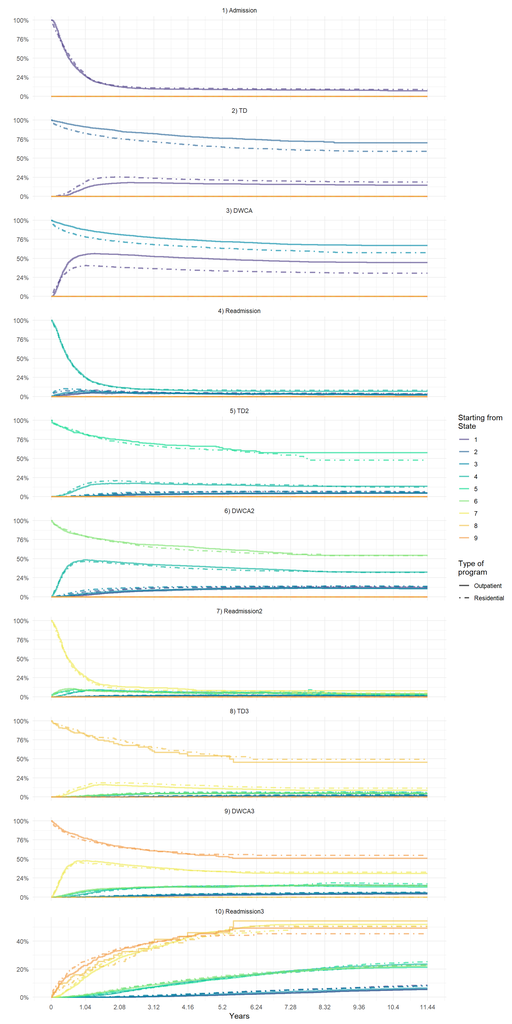

Figure 3. Estimate of State Occupancies at Baseline, Ten-states model

```r
#pmatrix_t_a_df_final pmatrix_t_b_df_final pmatrix_4s_t_a_df_final pmatrix_4s_t_b_df_final

states_trans_lab<-paste0(1:10,") ",states_trans)
attr(states_trans_lab,"names")<-1:10

ab_pmatrix<-
  pmatrix_cox_a_0 %>%
  dplyr::left_join(pmatrix_cox_b_0, by="time", suffix=c("",".w_covs.res.s1")) %>%
  dplyr::left_join(pmatrix_cox_a_0_s2, by="time", suffix=c("",".w_covs.out.s2")) %>%
  dplyr::left_join(pmatrix_cox_b_0_s2, by="time", suffix=c("",".w_covs.res.s2")) %>%
  dplyr::left_join(pmatrix_cox_a_0_s3, by="time", suffix=c("",".w_covs.out.s3")) %>%
  dplyr::left_join(pmatrix_cox_b_0_s3, by="time", suffix=c("",".w_covs.res.s3")) %>%
  dplyr::left_join(pmatrix_cox_a_0_s4, by="time", suffix=c("",".w_covs.out.s4")) %>%
  dplyr::left_join(pmatrix_cox_b_0_s4, by="time", suffix=c("",".w_covs.res.s4")) %>%
  dplyr::left_join(pmatrix_cox_a_0_s5, by="time", suffix=c("",".w_covs.out.s5")) %>%
  dplyr::left_join(pmatrix_cox_b_0_s5, by="time", suffix=c("",".w_covs.res.s5")) %>%
  dplyr::left_join(pmatrix_cox_a_0_s6, by="time", suffix=c("",".w_covs.out.s6")) %>%
  dplyr::left_join(pmatrix_cox_b_0_s6, by="time", suffix=c("",".w_covs.res.s6")) %>%
  dplyr::left_join(pmatrix_cox_a_0_s7, by="time", suffix=c("",".w_covs.out.s7")) %>%
  dplyr::left_join(pmatrix_cox_b_0_s7, by="time", suffix=c("",".w_covs.res.s7")) %>%
  dplyr::left_join(pmatrix_cox_a_0_s8, by="time", suffix=c("",".w_covs.out.s8")) %>%
  dplyr::left_join(pmatrix_cox_b_0_s8, by="time", suffix=c("",".w_covs.res.s8")) %>%
  dplyr::left_join(pmatrix_cox_a_0_s9, by="time", suffix=c("",".w_covs.out.s9")) %>%
  dplyr::left_join(pmatrix_cox_b_0_s9, by="time", suffix=c("",".w_covs.res.s9")) %>%
  dplyr::rename("pstate1.w_covs.out.s1"="pstate1",
                "pstate2.w_covs.out.s1"="pstate2",
                "pstate3.w_covs.out.s1"="pstate3",
                "pstate4.w_covs.out.s1"="pstate4",
                "pstate5.w_covs.out.s1"="pstate5",
                "pstate6.w_covs.out.s1"="pstate6",
                "pstate7.w_covs.out.s1"="pstate7",
                "pstate8.w_covs.out.s1"="pstate8",
                "pstate9.w_covs.out.s1"="pstate9",
                "pstate10.w_covs.out.s1"="pstate10") %>%
  #pstate1–pstate3 are close to the first rows of the matrices returned by pmatrix.fs
  reshape2::melt(id.vars="time") %>% #janitor::tabyl(variable)
  dplyr::mutate(start=stri_sub(variable,-1,-1)) %>%
  dplyr::mutate(state=stringi::stri_match_first_regex(variable, "(.*?)\\.")[,2]) %>%
  dplyr::mutate(state=gsub("pstate", "", state), state=as.numeric(state)) %>%
  dplyr::mutate(setting= dplyr::case_when(grepl(".out",variable)~"Outpatient",
                                               grepl(".res",variable)~"Residential",
                                               T~NA_character_))

fig_ab_pmatrix<-
  #janitor::tabyl(start)
ggplot(ab_pmatrix, aes(time, value, color= start, linetype =setting))+
  geom_step(size=1, alpha=.65) +
  scale_y_continuous(labels = scales::percent_format(accuracy = 2))+
  facet_wrap(state~., ncol=1, scales="free_y", labeller = as_labeller(states_trans_lab)) +
  #facet_wrap(state~., ncol=1, scales="free_y") + #type_of_program
  scale_color_manual(name = "Starting from\nState", values=c("#54478C","#2C699A","#048BA8","#0DB39E",
                                                      "#16DB93","#83E377","#EFEA5A","#F1C453","#F29E4C"), labels= as.character(c(1:9))) + # "#A65100" #"Cox",
  scale_linetype_manual(name= "Type of\nprogram",values=c(1,4), labels=c("Outpatient","Residential")) +
  scale_x_continuous(breaks=seq(0,max(c(msf0$Haz$time,msf1$Haz$time),na.rm=T),by=max(c(msf0$Haz$time,msf1$Haz$time),na.rm=T)/11),
                     label=round(seq(0,max(c(msf0$Haz$time,msf1$Haz$time),na.rm=T),by=max(c(msf0$Haz$time,msf1$Haz$time),na.rm=T)/11)/365.25,2))+
  xlab("Years") +
  ylab("") +
  theme_minimal()

fig_ab_pmatrix
```

```r
if(no_mostrar==1){
jpeg("eso17.jpg", height=20, width= 10, res= 320, units = "in")
fig_ab_pmatrix
dev.off()
}
```

## Landmark Aalen-Johansen

```r
#devtools::install_github("hputter/mstate")
invisible(c("For semi-Markov models, mstate provides the function mssample to produce both simulated trajectories and transition probability matrices from semi-Markov models, given the estimated piecewise-constant cumulative hazards (Fiocco et al. 2008), produced by msfit or msfit.flexsurvreg, though this is generally less efficient than pmatrix.simfs. In this example, 1000 samples from mssample give estimates of transition probabilities that are accurate to within around 0.02. However with pmatrix.simfs, greater precision is achieved by simulating 100 times as many trajectories in a shorter time"))

time_before_LMAJ<-Sys.time()

trans_df<-cbind.data.frame(transition_label,trans=1:max(trans_matrix,na.rm=T))

lmaj_df<-data.frame()
for (transo in 1:9){
  if(tryCatch({LMAJ(pr0,from=transo,s=1,method="aalen")}, error=function(e) {data.frame()}) %>% data.frame() %>% nrow()>0){
  lmaj_df<- rbind.data.frame(lmaj_df,
     cbind(pr="out",
                  LMAJ(pr0, #An "msdata" object, as for instance prepared by link{msprep}
                  from=transo, ##Either a single state or a set of states in the state space 1,...,S
                  s=1,  #The prediction time point s from which transition probabilities are to be obtained
                  method ="aalen" #The method for calculating variances, as in probtrans
                  ),transo=transo))
  } else if (tryCatch({LMAJ(pr1,from=transo,s=1,method="aalen")}, error=function(e) {data.frame()}) %>% data.frame() %>% nrow()>0){
    lmaj_df<- rbind.data.frame(lmaj_df,
     cbind(pr="out",
                  LMAJ(pr1, #An "msdata" object, as for instance prepared by link{msprep}
                  from=transo, ##Either a single state or a set of states in the state space 1,...,S
                  s=1,  #The prediction time point s from which transition probabilities are to be obtained
                  method ="aalen" #The method for calculating variances, as in probtrans
                  ),transo=transo))
    } else {rep(0,21)
  }
}
pr0_sel<-pr0[,c("id", "from", "to", "trans", "Tstart", "Tstop", "time", "status", "tipo_de_plan_res_1")]
attr(pr0_sel,"trans")<-trans_matrix

pr1_sel<-pr1[,c("id", "from", "to", "trans", "Tstart", "Tstop", "time", "status", "tipo_de_plan_res_1")]
attr(pr1_sel,"trans")<-trans_matrix

lmaj_out_1<-
LMAJ(pr0_sel, #An "msdata" object, as for instance prepared by link{msprep}
                  from=1, ##Either a single state or a set of states in the state space 1,...,S
                  s=1,  #The prediction time point s from which transition probabilities are to be obtained
                  method ="aalen" #The method for calculating variances, as in probtrans
                  )
lmaj_out_2<-
LMAJ(pr0_sel, #An "msdata" object, as for instance prepared by link{msprep}
                  from=2, ##Either a single state or a set of states in the state space 1,...,S
                  s=1,  #The prediction time point s from which transition probabilities are to be obtained
                  method ="aalen" #The method for calculating variances, as in probtrans
                  )
```

```
## Error in coxph(Surv(Tstart, Tstop, status) ~ strata(trans), data = msdatasfrom): No (non-missing) observations
```

```r
lmaj_out_3<-
LMAJ(pr0_sel, #An "msdata" object, as for instance prepared by link{msprep}
                  from=3, ##Either a single state or a set of states in the state space 1,...,S
                  s=1,  #The prediction time point s from which transition probabilities are to be obtained
                  method ="aalen" #The method for calculating variances, as in probtrans
                  )
lmaj_out_4<-
LMAJ(pr0_sel, #An "msdata" object, as for instance prepared by link{msprep}
                  from=4, ##Either a single state or a set of states in the state space 1,...,S
                  s=1,  #The prediction time point s from which transition probabilities are to be obtained
                  method ="aalen" #The method for calculating variances, as in probtrans
                  )
```

```
## Error in coxph(Surv(Tstart, Tstop, status) ~ strata(trans), data = msdatasfrom): No (non-missing) observations
```

```r
lmaj_out_5<-
LMAJ(pr0_sel, #An "msdata" object, as for instance prepared by link{msprep}
                  from=5, ##Either a single state or a set of states in the state space 1,...,S
                  s=1,  #The prediction time point s from which transition probabilities are to be obtained
                  method ="aalen" #The method for calculating variances, as in probtrans
                  )
```

```
## Error in coxph(Surv(Tstart, Tstop, status) ~ strata(trans), data = msdatasfrom): No (non-missing) observations
```

```r
lmaj_out_6<-
LMAJ(pr0_sel, #An "msdata" object, as for instance prepared by link{msprep}
                  from=6, ##Either a single state or a set of states in the state space 1,...,S
                  s=1,  #The prediction time point s from which transition probabilities are to be obtained
                  method ="aalen" #The method for calculating variances, as in probtrans
                  )
```

```
## Error in coxph(Surv(Tstart, Tstop, status) ~ strata(trans), data = msdatasfrom): No (non-missing) observations
```

```r
lmaj_out_7<-
LMAJ(pr0_sel, #An "msdata" object, as for instance prepared by link{msprep}
                  from=7, ##Either a single state or a set of states in the state space 1,...,S
                  s=1,  #The prediction time point s from which transition probabilities are to be obtained
                  method ="aalen" #The method for calculating variances, as in probtrans
                  )
```

```
## Error in coxph(Surv(Tstart, Tstop, status) ~ strata(trans), data = msdatasfrom): No (non-missing) observations
```

```r
lmaj_out_8<-
LMAJ(pr0_sel, #An "msdata" object, as for instance prepared by link{msprep}
                  from=8, ##Either a single state or a set of states in the state space 1,...,S
                  s=1,  #The prediction time point s from which transition probabilities are to be obtained
                  method ="aalen" #The method for calculating variances, as in probtrans
                  )
```

```
## Error in coxph(Surv(Tstart, Tstop, status) ~ strata(trans), data = msdatasfrom): No (non-missing) observations
```

```r
lmaj_out_9<-
LMAJ(pr0_sel, #An "msdata" object, as for instance prepared by link{msprep}
                  from=9, ##Either a single state or a set of states in the state space 1,...,S
                  s=1,  #The prediction time point s from which transition probabilities are to be obtained
                  method ="aalen" #The method for calculating variances, as in probtrans
                  )
```

```
## Error in coxph(Surv(Tstart, Tstop, status) ~ strata(trans), data = msdatasfrom): No (non-missing) observations
```

```r
lmaj_res_1<-
LMAJ(pr1_sel, #An "msdata" object, as for instance prepared by link{msprep}
                  from=1, ##Either a single state or a set of states in the state space 1,...,S
                  s=1,  #The prediction time point s from which transition probabilities are to be obtained
                  method ="aalen" #The method for calculating variances, as in probtrans
                  )
lmaj_res_2<-
LMAJ(pr1_sel, #An "msdata" object, as for instance prepared by link{msprep}
                  from=2, ##Either a single state or a set of states in the state space 1,...,S
                  s=1,  #The prediction time point s from which transition probabilities are to be obtained
                  method ="aalen" #The method for calculating variances, as in probtrans
                  )
lmaj_res_3<-
LMAJ(pr1_sel, #An "msdata" object, as for instance prepared by link{msprep}
                  from=3, ##Either a single state or a set of states in the state space 1,...,S
                  s=1,  #The prediction time point s from which transition probabilities are to be obtained
                  method ="aalen" #The method for calculating variances, as in probtrans
                  )
lmaj_res_4<-
LMAJ(pr1_sel, #An "msdata" object, as for instance prepared by link{msprep}
                  from=4, ##Either a single state or a set of states in the state space 1,...,S
                  s=1,  #The prediction time point s from which transition probabilities are to be obtained
                  method ="aalen" #The method for calculating variances, as in probtrans
                  )
```

```
## Error in coxph(Surv(Tstart, Tstop, status) ~ strata(trans), data = msdatasfrom): No (non-missing) observations
```

```r
lmaj_res_5<-
LMAJ(pr1_sel, #An "msdata" object, as for instance prepared by link{msprep}
                  from=5, ##Either a single state or a set of states in the state space 1,...,S
                  s=1,  #The prediction time point s from which transition probabilities are to be obtained
                  method ="aalen" #The method for calculating variances, as in probtrans
                  )
```

```
## Error in coxph(Surv(Tstart, Tstop, status) ~ strata(trans), data = msdatasfrom): No (non-missing) observations
```

```r
lmaj_res_6<-
LMAJ(pr1_sel, #An "msdata" object, as for instance prepared by link{msprep}
                  from=6, ##Either a single state or a set of states in the state space 1,...,S
                  s=1,  #The prediction time point s from which transition probabilities are to be obtained
                  method ="aalen" #The method for calculating variances, as in probtrans
                  )
```

```
## Error in coxph(Surv(Tstart, Tstop, status) ~ strata(trans), data = msdatasfrom): No (non-missing) observations
```

```r
lmaj_res_7<-
LMAJ(pr1_sel, #An "msdata" object, as for instance prepared by link{msprep}
                  from=7, ##Either a single state or a set of states in the state space 1,...,S
                  s=1,  #The prediction time point s from which transition probabilities are to be obtained
                  method ="aalen" #The method for calculating variances, as in probtrans
                  )
```

```
## Error in coxph(Surv(Tstart, Tstop, status) ~ strata(trans), data = msdatasfrom): No (non-missing) observations
```

```r
lmaj_res_8<-
LMAJ(pr1_sel, #An "msdata" object, as for instance prepared by link{msprep}
                  from=8, ##Either a single state or a set of states in the state space 1,...,S
                  s=1,  #The prediction time point s from which transition probabilities are to be obtained
                  method ="aalen" #The method for calculating variances, as in probtrans
                  )
```

```
## Error in coxph(Surv(Tstart, Tstop, status) ~ strata(trans), data = msdatasfrom): No (non-missing) observations
```

```r
lmaj_res_9<-
LMAJ(pr1_sel, #An "msdata" object, as for instance prepared by link{msprep}
                  from=9, ##Either a single state or a set of states in the state space 1,...,S
                  s=1,  #The prediction time point s from which transition probabilities are to be obtained
                  method ="aalen" #The method for calculating variances, as in probtrans
                  )
```

```
## Error in coxph(Surv(Tstart, Tstop, status) ~ strata(trans), data = msdatasfrom): No (non-missing) observations
```

```r
#if (nrow(mf) ==0) stop("No (non-missing) observations")


time_after_LMAJ<-Sys.time()

#LMAJ(pr1,from=1,s=90,method="aalen")

paste0("Time in process: ");time_after_LMAJ-time_before_LMAJ
```

```
## [1] "Time in process: "
```

```
## Time difference of 1.419434 mins
```

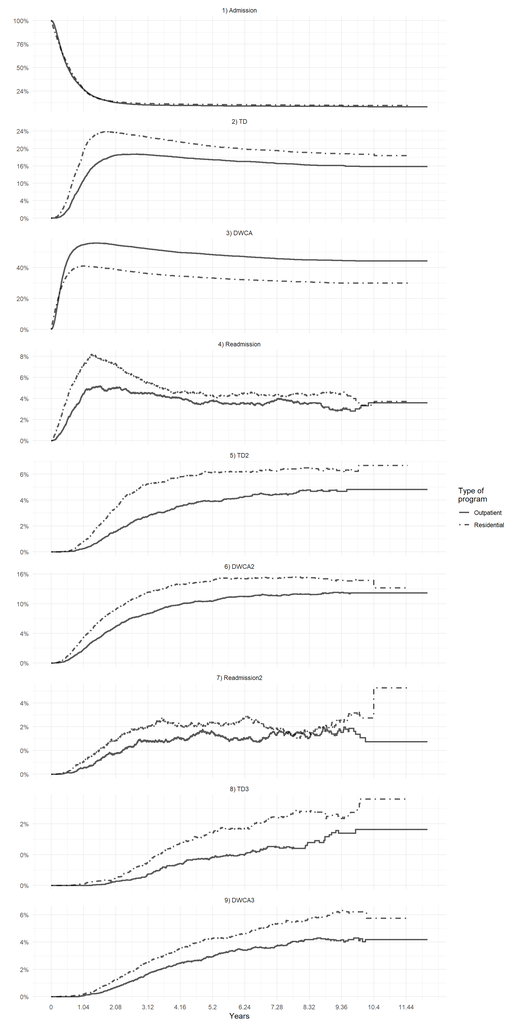

Figure 4. State Occupancies, landmark Aalen-Johansen estimator

```r
#A data frame containing estimates and associated standard errors of the transition probabilities P(X(t)=k | X(s) in from) with s and from the arguments of the function.

#View(lmaj_df %>% dplyr::mutate_at(3:22,~round(.,2)) %>% dplyr::filter(time==90))
#View(lmaj_df %>% dplyr::mutate_at(3:22,~round(.,2)))

lmaj_plot<-
rbind(cbind(pr="res",lmaj_res_1,transo=1),
      cbind(pr="out",lmaj_out_1,transo=1)) %>%
  melt(id.vars=c("pr","transo","time")) %>%
  dplyr::rename("state_from"="transo") %>%
  dplyr::mutate(state_to=stri_sub(variable,-1,-1)) %>%
    dplyr::mutate(setting= dplyr::case_when(grepl("out",pr)~"Outpatient",
                                            grepl("res",pr)~"Residential",
                                            T~NA_character_)) %>%
      dplyr::mutate(measure= dplyr::case_when(grepl("se",variable)~"se",
                                            grepl("pstate",variable)~"Estimate",
                                            T~NA_character_)) %>%
  dplyr::select(-pr,-variable) %>%
  tidyr::pivot_wider(names_from=measure,values_from = value) %>%
  dplyr::filter(state_from>0, state_to>0) %>%
  purrr::when(dplyr::group_by(.,time, state_from, state_to, setting) %>% summarise(n=n()) %>% dplyr::filter(n>1)%>% nrow()>0 ~ stop("There are cases with differences different than 0 days of a variable that should be equal"),
            ~.) %>%
  dplyr::mutate(state_from=factor(state_from),state_to=factor(state_to), setting=factor(setting)) %>%
  ggplot(aes(time, Estimate, linetype =setting))+
  geom_step(size=1, alpha=.65) +
  facet_wrap(state_to~., ncol=1, scales="free_y", labeller = as_labeller(states_trans_lab)) +
  scale_y_continuous(labels = scales::percent_format(accuracy = 2))+
  #facet_wrap(state~., ncol=1, scales="free_y") + #type_of_program
  scale_color_manual(name = "Starting from\nState", values=c("#54478C","#2C699A","#048BA8","#0DB39E",
                                                      "#16DB93","#83E377","#EFEA5A","#F1C453","#F29E4C"), labels= as.character(c(1:9))) + # "#A65100" #"Cox",
  scale_linetype_manual(name= "Type of\nprogram",values=c(1,4), labels=c("Outpatient","Residential")) +
  scale_x_continuous(breaks=seq(0,max(c(msf0$Haz$time,msf1$Haz$time),na.rm=T),by=max(c(msf0$Haz$time,msf1$Haz$time),na.rm=T)/11),
                     label=round(seq(0,max(c(msf0$Haz$time,msf1$Haz$time),na.rm=T),by=max(c(msf0$Haz$time,msf1$Haz$time),na.rm=T)/11)/365.25,2))+
  xlab("Years") +
  ylab("") +
  theme_minimal()
lmaj_plot
```

```r
if(no_mostrar==1){
jpeg("eso17.jpg", height=20, width= 10, res= 320, units = "in")
lmaj_plot
dev.off()
}
```